# Weight lifting analysis

S. Menon

Feb 04, 2018

# 1 Background

In this project, the goal is to use data from accelerometers on the belt, forearm, arm, and dumbell of 6 participants.They were asked to perform barbell lifts correctly and incorrectly in 5 different ways.

Six young health participants were asked to perform one set of 10 repetitions of the Unilateral Dumbbell Biceps Curl in five different fashions: exactly according to the specification (Class A), throwing the elbows to the front (Class B), lifting the dumbbell only halfway (Class C), lowering the dumbbell only halfway (Class D) and throwing the hips to the front (Class E).

A training sample was given to build the model and test file to predict the outcome Source of data http://web.archive.org/web/20161224072740/http:/groupware.les.inf.puc-rio.br/har

# 2 Upload Data

Data is uploaded, and there are about 160 variables. A lot of the columns are NA or have errors. Hence all columns invalid data was ignored.

```r
trainData <- read.csv(file="C:/Users/smenon/Documents/Coursera/Practical ML/pml-training.csv",
                      na.strings=c('#DIV/0', '', 'NA') ,stringsAsFactors = F,header = TRUE)
testData <- read.csv(file="C:/Users/smenon/Documents/Coursera/Practical ML/pml-testing.csv",
                     na.strings=c('#DIV/0', '', 'NA') ,stringsAsFactors = F,header = TRUE)
dim(trainData)
```

```
## [1] 19622   160
```

```r
dim(testData)
```

```
## [1]  20 160
```

```r
noNAtrainData = trainData[ , colSums(is.na(trainData)) == 0]
dim(trainData)
```

```
## [1] 19622   160
```

```r
#str(trainData)
```

# 3 Model Build

Next step is to build the model. First step is to split the data into train and test groups

## 3.1 Create Test and hold-out samples

```r
inTrain <- createDataPartition(y=noNAtrainData$classe,p=0.7,list=FALSE)
training <- noNAtrainData[inTrain,]
testing <- noNAtrainData[-inTrain,]
dim(training); dim(testing)
```

```
## [1] 13737    60
```

```
## [1] 5885   60
```

## 3.2 Build Segmentation Tree

```r
fit <- rpart(as.factor(classe) ~ as.factor(user_name) +
             new_window+num_window+roll_belt+
             pitch_belt+yaw_belt+total_accel_belt+gyros_belt_x+
             gyros_belt_y+gyros_belt_z+accel_belt_x+accel_belt_y+
             accel_belt_z+magnet_belt_x+magnet_belt_y+magnet_belt_z+
             roll_arm+pitch_arm+yaw_arm+total_accel_arm+
             gyros_arm_x+gyros_arm_y+gyros_arm_z+accel_arm_x+
             accel_arm_y+accel_arm_z+magnet_arm_x+magnet_arm_y+
             magnet_arm_z+roll_dumbbell+pitch_dumbbell+yaw_dumbbell+
             total_accel_dumbbell+gyros_dumbbell_x+gyros_dumbbell_y+gyros_dumbbell_z+
             accel_dumbbell_x+accel_dumbbell_y+accel_dumbbell_z+magnet_dumbbell_x+
             magnet_dumbbell_y+magnet_dumbbell_z+roll_forearm+pitch_forearm+
             yaw_forearm+total_accel_forearm+gyros_forearm_x+gyros_forearm_y+
             gyros_forearm_z+accel_forearm_x+accel_forearm_y+accel_forearm_z+
             magnet_forearm_x+magnet_forearm_y+magnet_forearm_z,
             data=training, method="class")
```

## 3.3 Plot Segmentation Tree

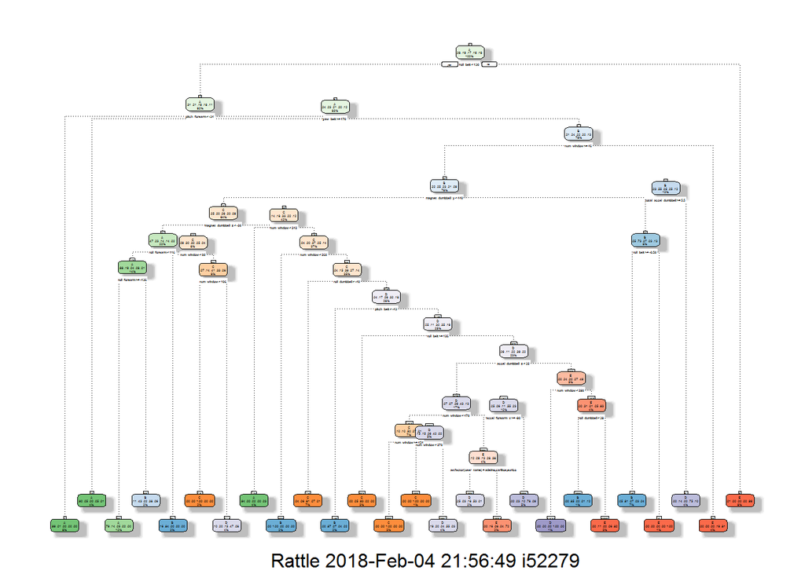

```r
fancyRpartPlot(fit)
```

## 3.4 Validate model using the hold-out sample

The table below shows comparison of predicted value and actual value of the holdout sample.

```r
pred <- predict(fit, newdata = testing,type="class")
testing$predRight <- pred==testing$classe
table(pred,testing$classe)
```

```
##
## pred    A    B    C    D    E
##    A 1501  112   50   32   19
##    B   53  791   49   72   34
##    C   16   40  814   24    1
##    D   98  145  102  761   91
##    E    6   51   11   75  937
```

# 4 Use the segmentation model to predict outcome of test sample provided

```r
testData$Prediction <- predict(fit, newdata = testData,type="class")
table(testData$user_name,testData$Prediction)
```

```
##
##            A B C D E
##   adelmo   1 0 0 0 0
##   carlitos 1 1 0 1 0
##   charles  1 0 0 0 0
##   eurico   1 2 0 0 1
##   jeremy   2 0 1 3 2
##   pedro    1 2 0 0 0
```

The table above below shows summary of predicted excercise type by user.

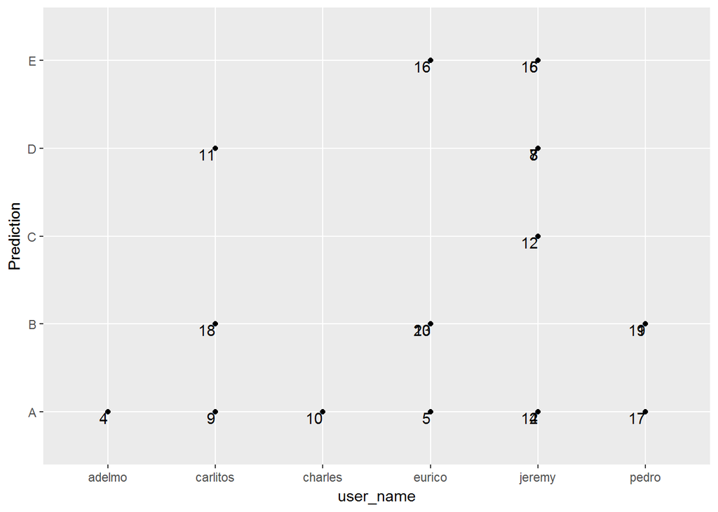

```r
ggplot(testData,aes(user_name,Prediction)) + geom_point()+geom_text(aes(label=problem_id),hjust=1,vjust=1)
```

The chart above provides similar view, with problem_id.